# Model Inferences

Kristian Brock

17 September, 2019

Modelling of the event rates in the observed series is presented in DLTSeriesPresentation and ObjRespSeriesPresentation. Inferences beyond those series-specific insights are explored here.

```r
# # This script in the root of the project loads the datasets
# source('../../../Load.R')

library(dplyr)
library(brms)
library(tidybayes)
library(ggplot2)
library(ggridges)
# Load DLT model and samples
dlt_mod <- readRDS('dlt_mod.rds')
dlt_fitted_draws <- readRDS('dlt_fitted_draws.rds')

# Load objective response model and samples
obj_resp_mod <- readRDS('obj_resp_mod.rds')
obj_resp_fitted_draws <- readRDS('obj_resp_fitted_draws.rds')
```

## DLT Model

### Fitted series

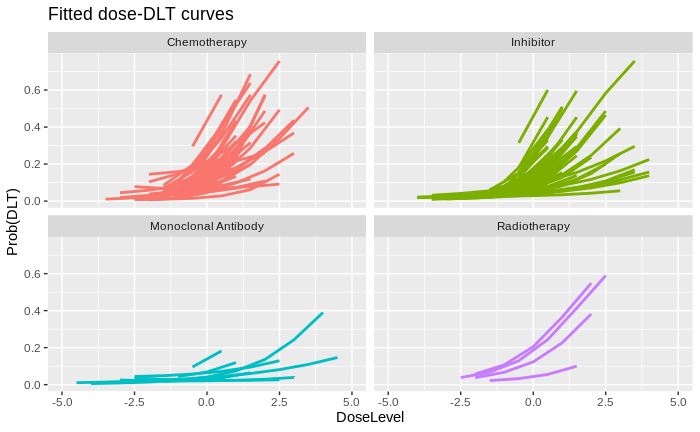

```r
dlt %>%
  left_join(studies, by = 'Study') %>%
  left_join(manuscripts, by = 'Manuscript') %>%
  filter(DoseVaryingTreatmentType %in% c('Chemotherapy',
                                         'Radiotherapy',
                                         'Monoclonal Antibody',
                                         'Inhibitor')) %>%
  add_fitted_draws(dlt_mod) %>%
  mutate(EstProbEvent = .value / n) %>%
  summarise(EstProbEvent = mean(EstProbEvent)) %>%
  ggplot(aes(x = DoseLevel, y = EstProbEvent, group = AnalysisSeriesId,
             col = DoseVaryingTreatmentType)) +
  geom_line(size = 1) +
  facet_wrap(~ DoseVaryingTreatmentType, ncol = 2) +
  xlim(-5, 5) +
  labs(title = 'Fitted dose-DLT curves', col = 'Drug type', y = 'Prob(DLT)') +
  theme(legend.position = 'none')
```

### Parameters

Intercept

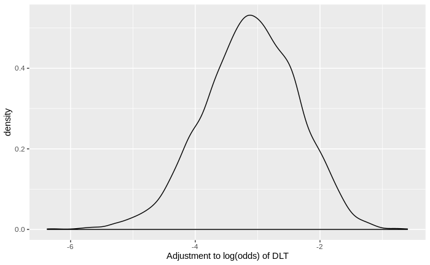

```r
dlt_mod %>%
  spread_draws(b_Intercept) %>%
  ggplot(aes(x = b_Intercept)) +
  geom_density() +
  labs(x = 'Adjustment to log(odds) of DLT') +
  theme(legend.position = 'none')
```

DoseLevel

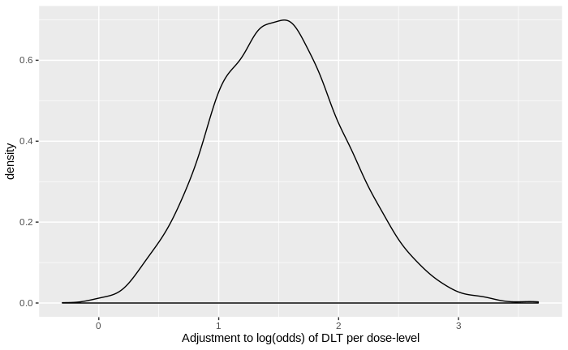

```r
dlt_mod %>%
  spread_draws(b_DoseLevel) %>%
  ggplot(aes(x = b_DoseLevel)) +
  geom_density() +
  labs(x = 'Adjustment to log(odds) of DLT per dose-level') +
  theme(legend.position = 'none')
```

Effect of ContainsChemo

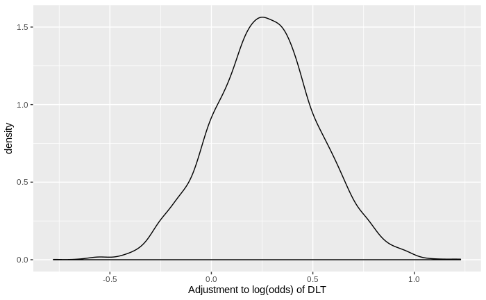

```r
dlt_mod %>%
  spread_draws(b_FixedDoseChemo) %>%
  ggplot(aes(x = b_FixedDoseChemo)) +
  geom_density() +
  labs(x = 'Adjustment to log(odds) of DLT') +
  theme(legend.position = 'none')
```

Effect of ChiuzanRuleBased1

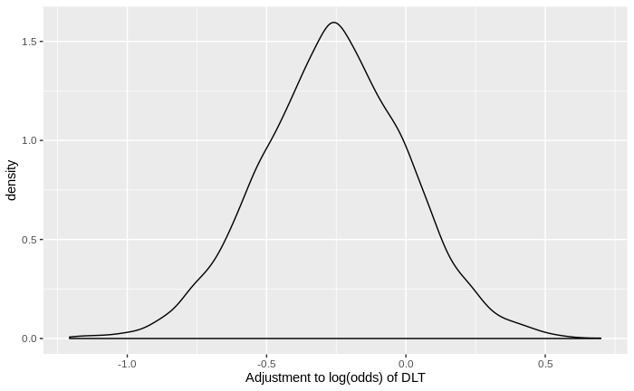

```r
dlt_mod %>%
  spread_draws(b_SourceChiuzanRuleBased1) %>%
  ggplot(aes(x = b_SourceChiuzanRuleBased1)) +
  geom_density() +
  labs(x = 'Adjustment to log(odds) of DLT') +
  theme(legend.position = 'none')
```

Effect of HaemNonhaemHaematological

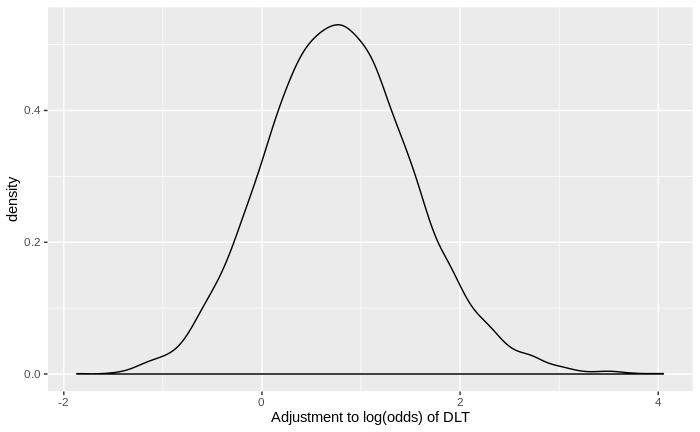

```r
dlt_mod %>%
  spread_draws(b_HaemNonhaemHaematological) %>%
  ggplot(aes(x = b_HaemNonhaemHaematological)) +
  geom_density() +
  labs(x = 'Adjustment to log(odds) of DLT') +
  theme(legend.position = 'none')
```

Effect of HaemNonhaemNonHaematological

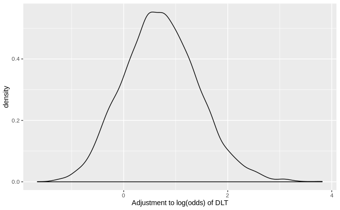

```r
dlt_mod %>%
  spread_draws(b_HaemNonhaemNonHaematological) %>%
  ggplot(aes(x = b_HaemNonhaemNonHaematological)) +
  geom_density() +
  labs(x = 'Adjustment to log(odds) of DLT') +
  theme(legend.position = 'none')
```

DoseLevel & ChiuzanRuleBased1

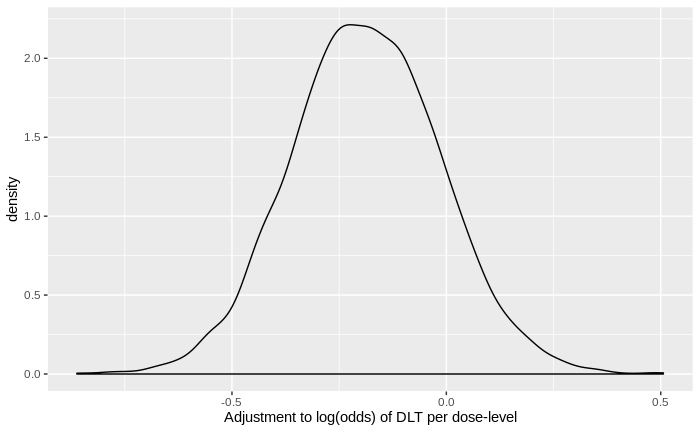

```r
dlt_mod %>%
  spread_draws(`b_DoseLevel:SourceChiuzanRuleBased1`) %>%
  ggplot(aes(x = `b_DoseLevel:SourceChiuzanRuleBased1`)) +
  geom_density() +
  labs(x = 'Adjustment to log(odds) of DLT per dose-level') +
  theme(legend.position = 'none')
```

DoseLevel & DoseLevel:HaemNonhaemHaematological

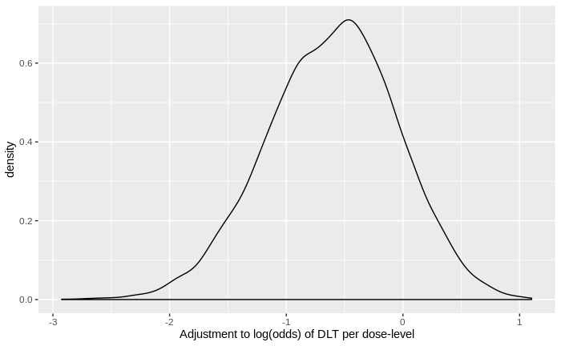

```r
dlt_mod %>%
  spread_draws(`b_DoseLevel:HaemNonhaemHaematological`) %>%
  ggplot(aes(x = `b_DoseLevel:HaemNonhaemHaematological`)) +
  geom_density() +
  labs(x = 'Adjustment to log(odds) of DLT per dose-level') +
  theme(legend.position = 'none')
```

DoseLevel & DoseLevel:HaemNonhaemNonHaematological

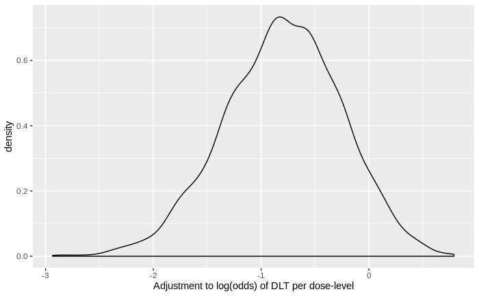

```r
dlt_mod %>%
  spread_draws(`b_DoseLevel:HaemNonhaemNonHaematological`) %>%
  ggplot(aes(x = `b_DoseLevel:HaemNonhaemNonHaematological`)) +
  geom_density() +
  labs(x = 'Adjustment to log(odds) of DLT per dose-level') +
  theme(legend.position = 'none')
```

Adjustments to baseline DLT rate for dose-varying-treatment type

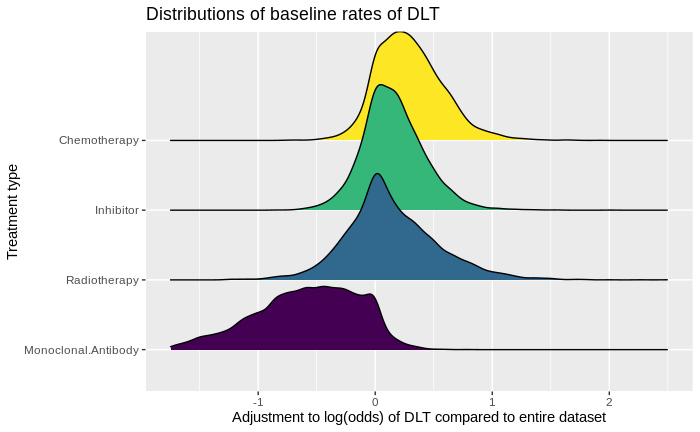

```r
dlt_mod %>%
    spread_draws(r_DoseVaryingTreatmentType[TmtType,term]) %>%
    filter(TmtType %in% c('Radiotherapy', 'Monoclonal.Antibody',
                          'Chemotherapy', 'Inhibitor')) %>%
    filter(term == 'Intercept') %>%
    rename(ParamValue = r_DoseVaryingTreatmentType) %>%
  mutate(TmtTypeO = factor(TmtType, levels = c('Monoclonal.Antibody',
                                                   'Radiotherapy',
                                                   'Inhibitor',
                                                   'Chemotherapy'),
                               ordered = TRUE)) %>%
  filter(term == 'Intercept') %>%
  ggplot(aes(y = TmtTypeO, group = TmtTypeO, fill = TmtTypeO,
             x = ParamValue)) +
  geom_density_ridges() +
  labs(x = 'Adjustment to log(odds) of DLT compared to entire dataset',
       y = 'Treatment type',
       title = 'Distributions of baseline rates of DLT') +
  theme(legend.position = 'none') +
  xlim(-1.75, 2.5)
```

After adjusting for the heterogeneity seen in the individual series, it appears that chemo is probably the therapy type with the greatest average risk of DLT. However, with inhibitors and radiotherapy, the risk of DLT is almost the same. The similarity in baseline rates may suggest that DLT is chosen mindful of therapy to be something that is likely to occur in a set proportion of patients. However, this would require admirable forecasting skills from trialists. Notably, incidence of DLT is less common in monoclonal antibodies.

Sensitivity of event to increases in dose

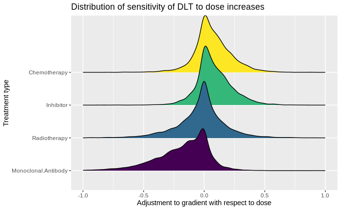

```r
dlt_mod %>%
  spread_draws(r_DoseVaryingTreatmentType[TmtType,term]) %>%
  filter(TmtType %in% c('Radiotherapy', 'Monoclonal.Antibody', 'Chemotherapy',
                        'Inhibitor')) %>%
  mutate(TmtTypeO = factor(TmtType, levels = c('Monoclonal.Antibody',
                                               'Radiotherapy',
                                               'Inhibitor',
                                               'Chemotherapy'),
                           ordered = TRUE)) %>%
  filter(term == 'DoseLevel') %>%
  ggplot(aes(y = TmtTypeO, group = TmtTypeO, fill = TmtTypeO,
             x = r_DoseVaryingTreatmentType)) +
  geom_density_ridges() +
  labs(x = 'Adjustment to gradient with respect to dose',
       y = 'Treatment type',
       title = 'Distribution of sensitivity of DLT to dose increases') +
  theme(legend.position = 'none') +
  xlim(-1, 1)
```

TODO - these need DoseLevel effect adding in now. With chemotherapies, inhibitors, and radiotherapy, the relationship of DLT risk with dose is concincingly positive. That is, greater doses of these treatments are associated with greater risk of DLT. The message is rather more opaque with antibodies. The aggregate evidence supports a positive relationship, but the strenght of the relationship is rather weaker than the other drug classes and could plausbily be very small.

All treatment types:

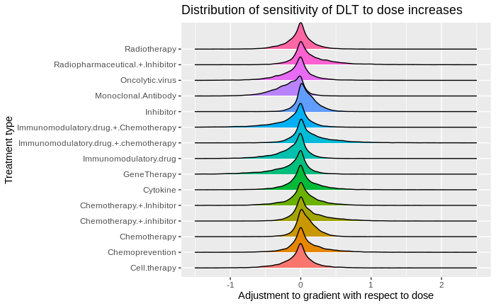

```r
dlt_mod %>%
  spread_draws(r_DoseVaryingTreatmentType[TmtType,term]) %>%
  filter(term == 'DoseLevel') %>%
  ggplot(aes(y = TmtType, group = TmtType, fill = TmtType,
             x = r_DoseVaryingTreatmentType)) +
  geom_density_ridges() +
  labs(x = 'Adjustment to gradient with respect to dose',
       y = 'Treatment type',
       title = 'Distribution of sensitivity of DLT to dose increases') +
  theme(legend.position = 'none') +
  xlim(-1.5, 2.5)
```

TODO: these need DoseLevel adding in now. And below There is more positive mass than negative mass, suggesting that the opposite must be seen in the AnalysisSeriesId-level analyses?

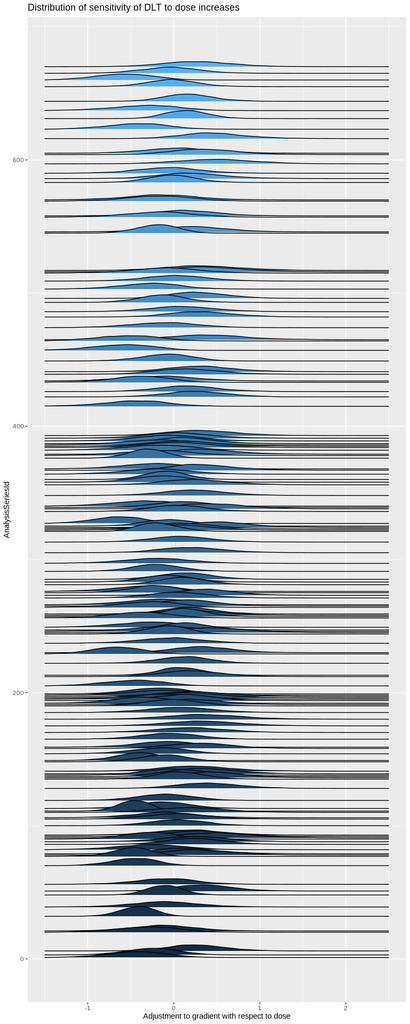

```r
dlt_mod %>%
  spread_draws(r_AnalysisSeriesId[AnalysisSeriesId,term]) %>%
  filter(term == 'DoseLevel') %>%
  ggplot(aes(y = AnalysisSeriesId, group = AnalysisSeriesId,
             fill = AnalysisSeriesId, x = r_AnalysisSeriesId)) +
  geom_density_ridges() +
  labs(x = 'Adjustment to gradient with respect to dose',
       title = 'Distribution of sensitivity of DLT to dose increases') +
  theme(legend.position = 'none') +
  xlim(-1.5, 2.5)
```

Woof. How would you know?

## Objective Response Model

### Fitted series

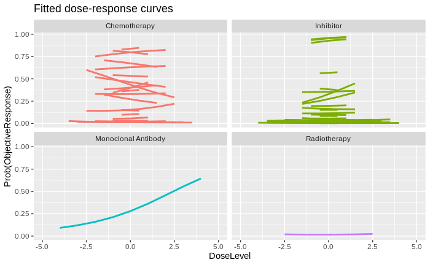

```r
obj_resp %>%
  filter(n > 0) %>%
  left_join(studies, by = 'Study') %>%
  left_join(manuscripts, by = 'Manuscript') %>%
  filter(DoseVaryingTreatmentType %in% c('Chemotherapy',
                                         'Radiotherapy',
                                         'Monoclonal Antibody',
                                         'Inhibitor')) %>%
  add_fitted_draws(obj_resp_mod) %>%
  mutate(EstProbEvent = .value / n) %>%
  summarise(EstProbEvent = mean(EstProbEvent)) %>%
  ggplot(aes(x = DoseLevel, y = EstProbEvent, group = AnalysisSeriesId,
             col = DoseVaryingTreatmentType)) +
  geom_line(size = 1) +
  facet_wrap(~ DoseVaryingTreatmentType, ncol = 2) +
  xlim(-5, 5) +
  labs(title = 'Fitted dose-response curves', col = 'Drug type',
       y = 'Prob(ObjectiveResponse)') +
  theme(legend.position = 'none')
```

Some series have seen no response at all. These could be medically inert molecules. Label the series:

```r
obj_resp %>% count(AnalysisSeriesId) %>% nrow  # 93 series
```

```
[1] 93
```

```r
# Tox in efficacious vs non-efficacious series
obj_resp %>%
  group_by(AnalysisSeriesId) %>%
  filter(n > 0) %>%
  summarise(TotalResp = sum(Events), TotalN = sum(n)) %>%
  mutate(RespRate = TotalResp / TotalN) %>%
  filter(TotalResp > 0) %>%
  mutate(Class = 'Responses seen') -> efficacious_series
efficacious_series %>% nrow  # 61 series
```

```
[1] 61
```

```r
obj_resp %>%
  group_by(AnalysisSeriesId) %>%
  filter(n > 0) %>%
  summarise(TotalResp = sum(Events), TotalN = sum(n)) %>%
  mutate(RespRate = TotalResp / TotalN) %>%
  filter(TotalResp == 0) %>%
  mutate(Class = 'No responses seen') -> non_efficacious_series
non_efficacious_series %>% nrow  # 32 series
```

```
[1] 32
```

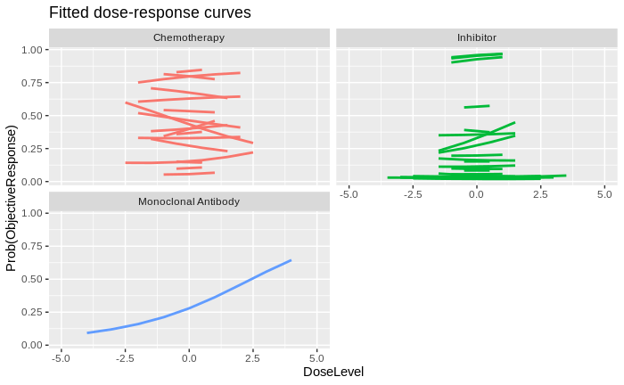

```r
obj_resp %>%
  filter(n > 0) %>%
  left_join(studies, by = 'Study') %>%
  left_join(manuscripts, by = 'Manuscript') %>%
  left_join(bind_rows(efficacious_series, non_efficacious_series),
            by = 'AnalysisSeriesId') %>%
  filter(DoseVaryingTreatmentType %in% c('Chemotherapy',
                                         'Radiotherapy',
                                         'Monoclonal Antibody',
                                         'Inhibitor')) %>%
  filter(Class == 'Responses seen') %>%
  add_fitted_draws(obj_resp_mod) %>%
  mutate(EstProbEvent = .value / n) %>%
  summarise(EstProbEvent = mean(EstProbEvent)) %>%
  ggplot(aes(x = DoseLevel, y = EstProbEvent, group = AnalysisSeriesId,
             col = DoseVaryingTreatmentType)) +
  geom_line(size = 1) +
  facet_wrap(~ DoseVaryingTreatmentType, ncol = 2) +
  xlim(-5, 5) +
  labs(title = 'Fitted dose-response curves', col = 'Drug type',
       y = 'Prob(ObjectiveResponse)') +
  theme(legend.position = 'none')
```

### Parameters

Intercept

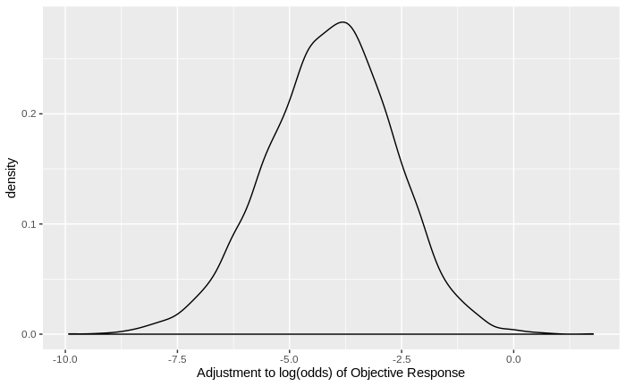

```r
obj_resp_mod %>%
  spread_draws(b_Intercept) %>%
  ggplot(aes(x = b_Intercept)) +
  geom_density() +
  labs(x = 'Adjustment to log(odds) of Objective Response') +
  theme(legend.position = 'none')
```

DoseLevel

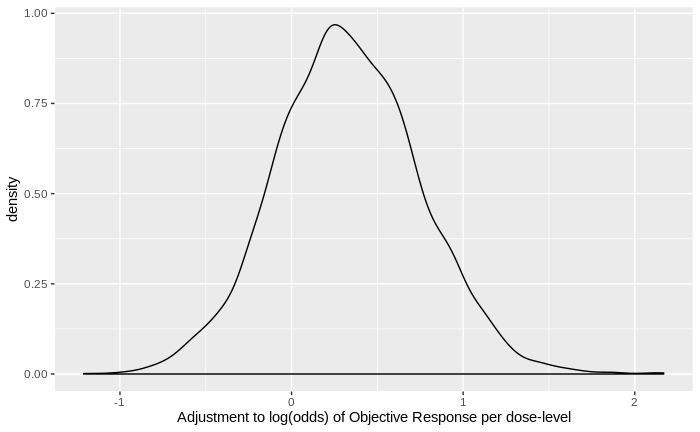

```r
obj_resp_mod %>%
  spread_draws(b_DoseLevel) %>%
  ggplot(aes(x = b_DoseLevel)) +
  geom_density() +
  labs(x = 'Adjustment to log(odds) of Objective Response per dose-level') +
  theme(legend.position = 'none')
```

Straddles zero.

Effect of ContainsChemo

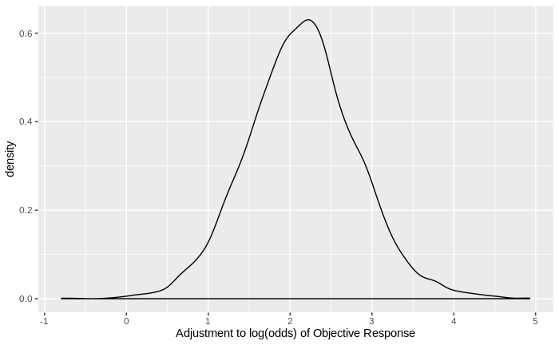

```r
obj_resp_mod %>%
  spread_draws(b_FixedDoseChemo) %>%
  ggplot(aes(x = b_FixedDoseChemo)) +
  geom_density() +
  labs(x = 'Adjustment to log(odds) of Objective Response') +
  theme(legend.position = 'none')
```

Response much more likely when chemo-backbone included.

Effect of ChiuzanRuleBased1

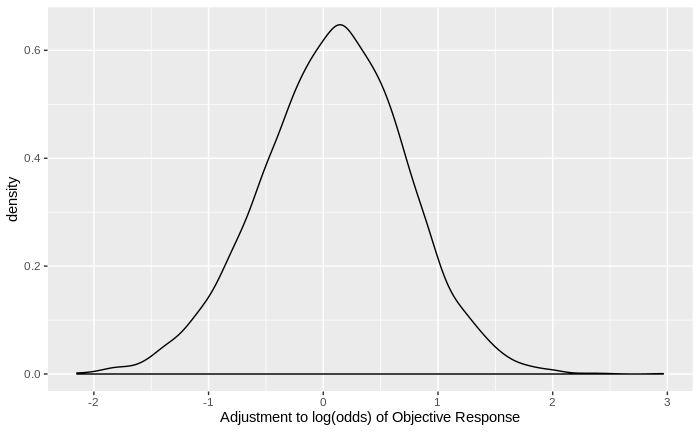

```r
obj_resp_mod %>%
  spread_draws(b_SourceChiuzanRuleBased1) %>%
  ggplot(aes(x = b_SourceChiuzanRuleBased1)) +
  geom_density() +
  labs(x = 'Adjustment to log(odds) of Objective Response') +
  theme(legend.position = 'none')
```

Effect of HaemNonhaemHaematological

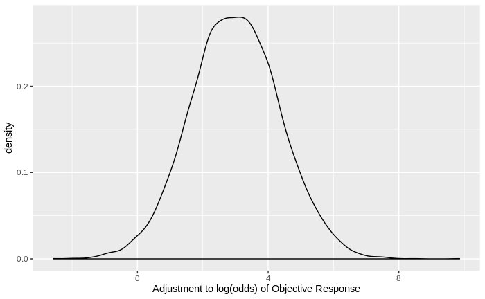

```r
obj_resp_mod %>%
  spread_draws(b_HaemNonhaemHaematological) %>%
  ggplot(aes(x = b_HaemNonhaemHaematological)) +
  geom_density() +
  labs(x = 'Adjustment to log(odds) of Objective Response') +
  theme(legend.position = 'none')
```

Much more likely to see response in Haem trials.

Effect of HaemNonhaemNonHaematological

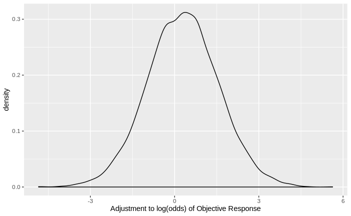

```r
obj_resp_mod %>%
  spread_draws(b_HaemNonhaemNonHaematological) %>%
  ggplot(aes(x = b_HaemNonhaemNonHaematological)) +
  geom_density() +
  labs(x = 'Adjustment to log(odds) of Objective Response') +
  theme(legend.position = 'none')
```

DoseLevel & ChiuzanRuleBased1

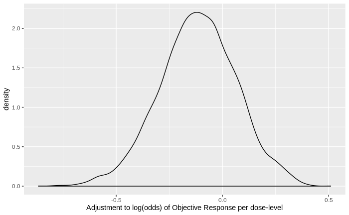

```r
obj_resp_mod %>%
  spread_draws(`b_DoseLevel:SourceChiuzanRuleBased1`) %>%
  ggplot(aes(x = `b_DoseLevel:SourceChiuzanRuleBased1`)) +
  geom_density() +
  labs(x = 'Adjustment to log(odds) of Objective Response per dose-level') +
  theme(legend.position = 'none')
```

DoseLevel & DoseLevel:HaemNonhaemHaematological

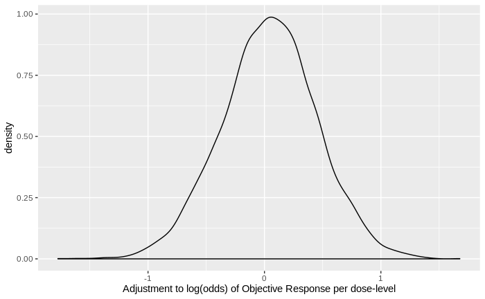

```r
obj_resp_mod %>%
  spread_draws(`b_DoseLevel:HaemNonhaemHaematological`) %>%
  ggplot(aes(x = `b_DoseLevel:HaemNonhaemHaematological`)) +
  geom_density() +
  labs(x = 'Adjustment to log(odds) of Objective Response per dose-level') +
  theme(legend.position = 'none')
```

DoseLevel & DoseLevel:HaemNonhaemNonHaematological

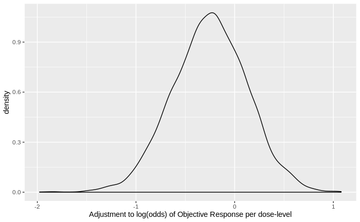

```r
obj_resp_mod %>%
  spread_draws(`b_DoseLevel:HaemNonhaemNonHaematological`) %>%
  ggplot(aes(x = `b_DoseLevel:HaemNonhaemNonHaematological`)) +
  geom_density() +
  labs(x = 'Adjustment to log(odds) of Objective Response per dose-level') +
  theme(legend.position = 'none')
```

Mean or baseline or expected event rate. Note that the baseline rate adjustment for chemo is no longer captured by one variable. The samples for the ContainsChemo intercept adjustment should be added to the Chemo random effects: TODO: does this make sense?

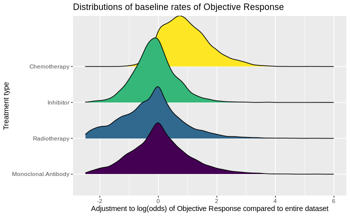

```r
obj_resp_mod %>%
    spread_draws(r_DoseVaryingTreatmentType[TmtType,term]) %>%
    filter(TmtType %in% c('Radiotherapy', 'Monoclonal.Antibody',
                          'Chemotherapy', 'Inhibitor')) %>%
    filter(term == 'Intercept') %>%
    rename(ParamValue = r_DoseVaryingTreatmentType) %>%
  mutate(TmtTypeO = factor(TmtType, levels = c('Monoclonal.Antibody',
                                                   'Radiotherapy',
                                                   'Inhibitor',
                                                   'Chemotherapy'),
                               ordered = TRUE)) %>%
  filter(term == 'Intercept') %>%
  ggplot(aes(y = TmtTypeO, group = TmtTypeO, fill = TmtTypeO,
             x = ParamValue)) +
  geom_density_ridges() +
  labs(x = 'Adjustment to log(odds) of Objective Response compared to entire dataset',
       y = 'Treatment type',
       title = 'Distributions of baseline rates of Objective Response') +
  theme(legend.position = 'none') +
  xlim(-2.5, 6)
```

Dose-varying chemo is associated with even greater chances of response. With other therapies, not.

Sensitivity of event to increases in dose

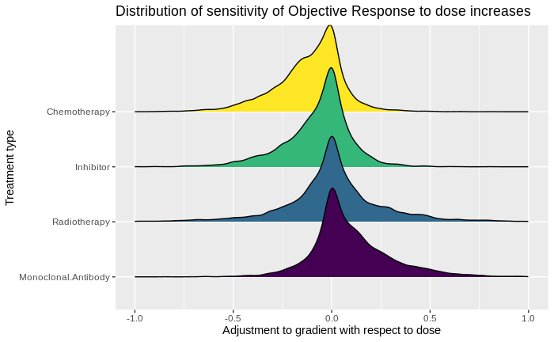

```r
obj_resp_mod %>%
  spread_draws(r_DoseVaryingTreatmentType[TmtType,term]) %>%
  filter(TmtType %in% c('Radiotherapy', 'Monoclonal.Antibody', 'Chemotherapy',
                        'Inhibitor')) %>%
  mutate(TmtTypeO = factor(TmtType, levels = c('Monoclonal.Antibody',
                                               'Radiotherapy',
                                               'Inhibitor',
                                               'Chemotherapy'),
                           ordered = TRUE)) %>%
  filter(term == 'DoseLevel') %>%
  ggplot(aes(y = TmtTypeO, group = TmtTypeO, fill = TmtTypeO,
             x = r_DoseVaryingTreatmentType)) +
  geom_density_ridges() +
  labs(x = 'Adjustment to gradient with respect to dose',
       y = 'Treatment type',
       title = 'Distribution of sensitivity of Objective Response to dose increases') +
  theme(legend.position = 'none') +
  xlim(-1.0, 1.0)
```

TODO this needs DoseLevel now